# Part II - Bikeshare Datasets Exploration for San Francisco, New York and Washington DC

## by Princewill Okechukwu

## Investigation Overview

For the Project Bikeshare Datasets Exploration for San Francisco, New York and Washington DC.

#### Some Key Questions that will be answered with Insights are as follows:

-What is the distribution of the varible of interest(Trip Duration - minutes) across the three cities?

-What is Trip Duration like for each day of the week?

-What is Trip duration like for each Period of day?

-What is the proportion of usertype for each gender ?

## Dataset Overview

The df_sf containing Bikeshare data for San Francisco Greater Bay Area contains 183412 observations with 16 variables, this is the primary dataset.The other 2 datasets are : -New York City dataset which contains 943744 observations and 15 variables. -Washington DC Metro area dataset which contains 158130 observations and 9 variables.

### What is the distribution of Trip Duration in minutes for the 3 Cities?

From the Log Plot of the 3 Trip Duration(min) we can see observe that the 3 Cities have somewhat similar shaped distribution. The Trip duration for the 3 Cities is fairly Unimodal, with San Francisco having close peaks around 8 minutes and 12 mins. New York City and Washington DC are Unimodal with their peaks around 8 minutes and 10 minutes respectively.

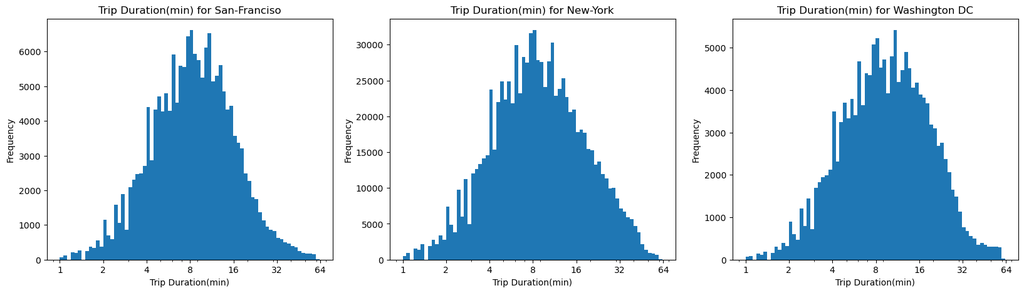

### What is Trip Duration Distribution by Period of Day

#### Our period of the day is as follows

```
     Early Morning: If the Hour of the day is less than 08:00

     Late Morning: If the Hour of the day is 09:00 or greater, but less than 12:00.

     Early Afternoon: If the Hour of the day is 12:00 or greater, but less than 15:00

     Late Afternoon: If the Hour of the day is 15:00 or greater, but less than 17:00

     Early Evening: If the Hour of the day is 17:00 or greater, but less than 20:00

     Late Evening: if the Hour of the day is 20:00 or greater
```

From the above investigation , It can be seen that Early afternoon(Periods Bewteen 12pm - 3pm) Has the largest interquartile range, these means the distribution of Trip duration varies mostly in early afternoon than other periods of the day, Early afternoon also has the max duration value across the 3 cities. Also the median duration for late evenings(8pm - midnight) tends to be the lowest for the 3 cities.

[figure not shown]

### What is Trip Duration By Day of the week?

From the box plots of day of week by duration, it can be observed that Saturday and Sundays have the biggest interquartile ranges for the 3 cities, This means that the duration for these days varies mostly Than the rest of the week.

[figure not shown]

### How is User type represented in Gender for San Franciso and New York City?

From the Clustered Bar Chart It can be observed that the ratio of customers to subscribers for both male and female groups in San Francisco is higher than that for New York.

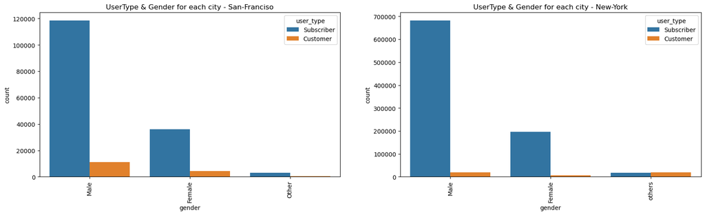